# Encuesta a estudiantes de Estadística Descriptiva y Análisis Exploratorio de Datos

Kenneth Roy Cabrera Torres

Martes, 20 de febrero de 2018

## ¿Cómo se perciben los estudiantes del curso de Estadśtica Descriptiva?

A los estudiantes de la asignatura de Estadística Descriptiva y Análisis Exploratorio de Datos se les preguntó por su Promedio Aritmético Ponderado Acumulado (PAPA) y también se les preguntó ¿Qué porcentaje de sus compañeros de la asignatura considera que está por encima de su PAPA?

### Análisis de la distribución del PAPA.

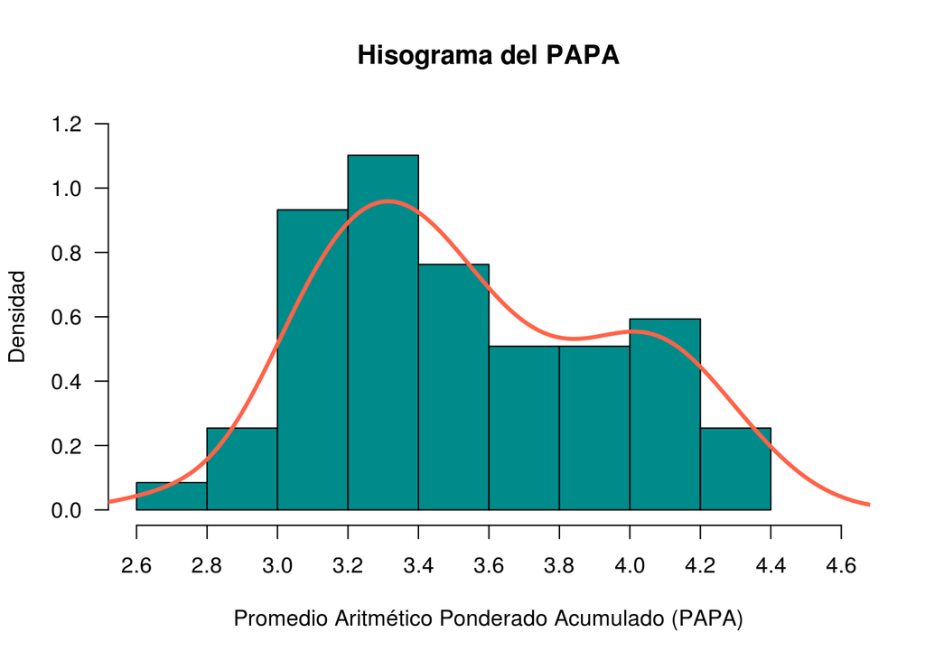

La distribución porcentual de cáda intervalo es:

```
##   limiteInf limiteSup  n densidad porcentaje
## 1       2.6       2.8  1    0.085        1.7
## 2       2.8       3.0  3    0.254        5.1
## 3       3.0       3.2 11    0.932       18.6
## 4       3.2       3.4 13    1.102       22.0
## 5       3.4       3.6  9    0.763       15.3
## 6       3.6       3.8  6    0.508       10.2
## 7       3.8       4.0  6    0.508       10.2
## 8       4.0       4.2  7    0.593       11.9
## 9       4.2       4.4  3    0.254        5.1
```

El promedio del PAPA de los encuestados fue de: 3.55 y la mediana fue de: 3.5.

De acuerdo una página wiki de [“Yo también soy unal”](http://es.tambinsoyunal.wikia.com/wiki/PAPA) se muestra la siguiente clasificación del PAPA:

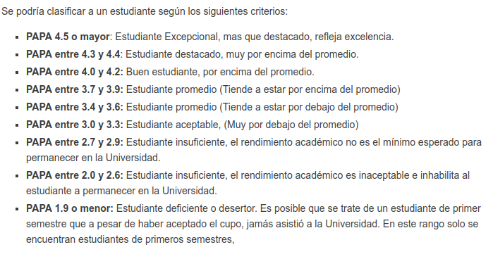

### Observaciones de la distribución del PAPA.

- La distribución del PAPA de los estudiantes de la asignatura Estadística Descriptiva y Análisis Exploratorio de datos del semestre 01 de 2018 muestra un comportamiento bimodal.
- De acuerdo a la clasifición el intervalo modal se encuentra en un desempeño por debajo del promedio general de la universidad.
- Un 17% se considera, de acuerdo a la clasificación se considera buen estudiante o destacado.

### Cálculos para establecer el verdadero porcentaje

Para comparar el porcentaje descrito por el estudiante en comparación con el porcentaje “verdadero”, se procedió a calcular el “verdadero porcentaje” mediante la siguiente fórmula.

$$Vporcentaje = \left[\frac{1-rango(x)}{n}\right] \times 100$$

### Gráfica porcentaje verdadero vs porcentaje estimado.

La siguiente gráfica muestra la relación entre el porcentaje verdadero y el porcentaje estimado por los estudiantes en la encuesta.

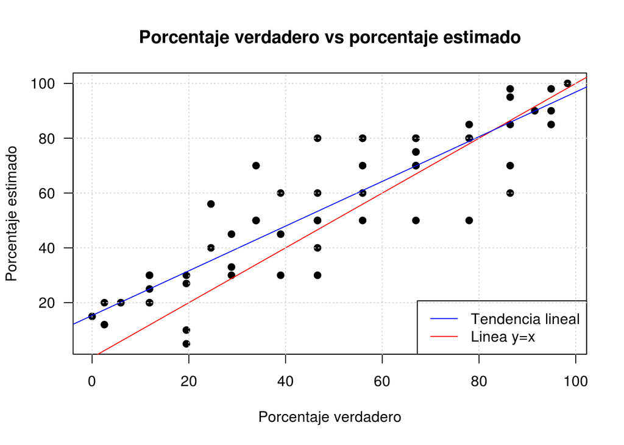

Para los niveles bajos de PAPA se hace una estimación acertada de su porcentaje con respecto al verdadero.

## Comportamiento del PAPA de acuerdo al semestre

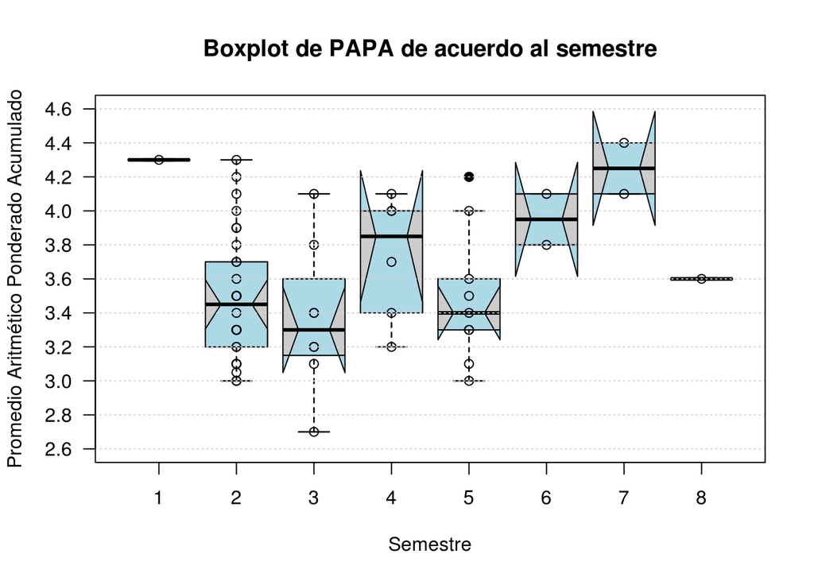

Es posible que el comportamiento bimodal del PAPA sea debido a la diferencia entre los niveles de semestre.

Falta observar si hay relación con la carrera.